# Fourier Domain Watermarking of Videos

```python
def example_usage_video_TD():
    video = load_video("input/meatthezoo.mp4")
    time = np.linspace(0, video.shape[0], video.shape[0])
    freq = 10
    N = len(time)
    watermark = np.sin(2 * np.pi * time * freq / N)

    plt.title("watermark frequency spectrum")
    plt.plot(time, (np.fft.fft(watermark)))
    plt.show()

    watermarked_video, key1, key2 = embed_video_watermark_TD(video, watermark, alpha = 10)

    plt.title("watermarked video vector")
    plt.plot(time, watermarked_video[:, key1, key2])
    plt.show()
    plt.title("video vector")
    plt.plot(time, video[:, key1, key2])
    plt.show()
    plt.title("difference of watermarked and original videos")
    diff = watermarked_video[:, key1, key2].astype(np.int16) - video[:, key1, key2].astype(np.int16)
    plt.plot(time, diff)
    plt.show()

    fig = plt.figure()
    video_frames = []
    for i in range(video.shape[0]):
        video_frames.append([plt.imshow(watermarked_video[i], cmap=cm.gray, animated=True, vmin=0, vmax=255)])

    video_ani = ArtistAnimation(fig, video_frames, interval=50, blit=True, repeat_delay=1000)

    output_dir = "output"
    os.makedirs(output_dir, exist_ok=True)
    video_ani.save(os.path.join(output_dir, "watermarked_video_TD.gif"), writer=PillowWriter(fps=20))
    print("Saved watermarked video to output/watermarked_video_TD.gif")


    extracted_watermark = extract_video_watermark_TD(video, watermarked_video, key1, key2, alpha=10)

    # Create figure with two subplots
    fig, (ax1, ax2) = plt.subplots(2, 1, figsize=(10, 8))

    # First subplot for the extracted watermark
    ax1.set_title("Frequency spikes of extracted watermark")
    ax1.plot(time, extracted_watermark)

    # Find the index of the max spike in the specified range
    search_range = extracted_watermark[0:len(time)//2]
    peak_index = np.argmax(search_range)
    peak_time = time[peak_index]

    # Add a dashed vertical line at the peak
    ax1.axvline(x=peak_time, color='r', linestyle='--', label=f'Peak at {peak_time:.2f}')
    ax1.legend()

    # Second subplot for the incorrect key extraction
    ax2.set_title("Extraction with incorrect keys")
    ax2.plot(time, extract_video_watermark_TD(video, watermarked_video, key1-1, key2-1, alpha=0.1))

    plt.tight_layout()
    plt.show()
```

[figure not shown]

[figure not shown]

[figure not shown]

```
Watermarking process completed successfully!
All output files saved to output/ directory.
```

```python
example_usage_image()
```

### Analysis

The results demonstrate the effectiveness of the DFT-based watermarking technique. The watermarked image spectrum shows the OpenAI logo watermark embedded in the image. The "Original Image" panel shows the unaltered input, while the "Watermarked Image" retains high visual fidelity, indicating that the watermark embedding process is imperceptible. The "Watermark" panel displays the binary pattern used for embedding. Notably, the "Extracted Watermark" panel reveals a clear and recognizable watermark, closely matching the original. This successful extraction underscores the robustness of the method, confirming that the watermark can be reliably retrieved without degrading the host image. Overall, the results validate the method's applicability for secure and imperceptible digital watermarking.

[figure not shown]

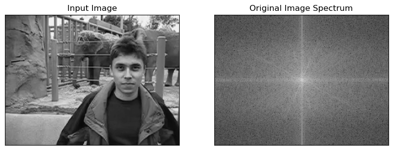

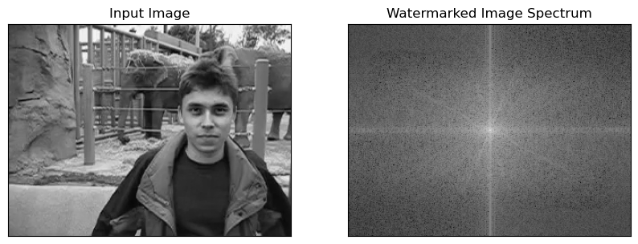

[output not shown]

[figure not shown]

```python
example_usage_video()
```

### Analysis

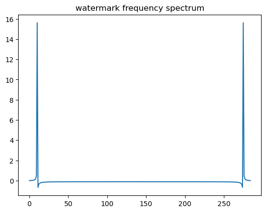

```
101 237
```

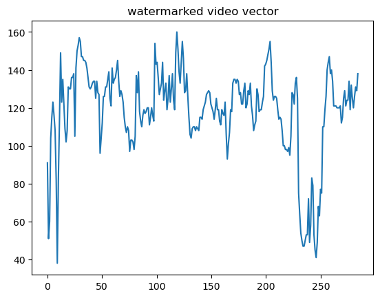

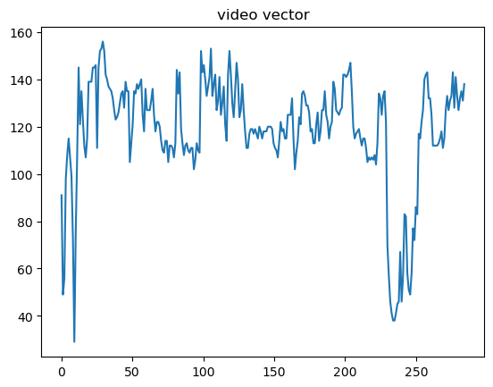

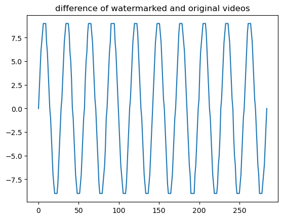

```
Saved watermarked video to output/watermarked_video_TD.gif
```

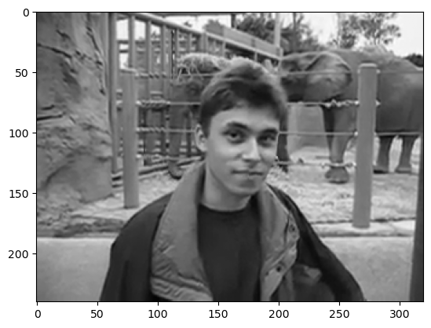

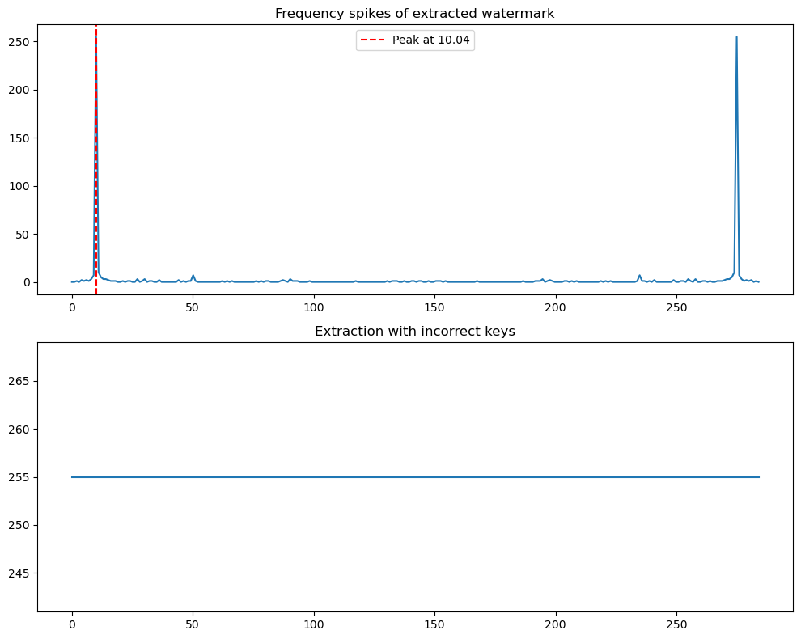

```python
example_usage_video_TD()
```